# Institution report

2022-08-31 08:15:04

# Purpose

This document creates a report of all of institutions affiliated in some way with Databrary.

## How to generate

1. Source the helper functions (`source("institutions-investigators/R/helpers.R")`) from the R console.
2. Execute `render_institutions_report(db_login, max_party_id)`, substituting your own Databrary login (email) for `db_login` and the maximum party_id value you want to use to update the institutions database.

# Update institutions

By default, this report updates the local institutions database. If you are running the report for the first time, the update may take awhile. It may be necessary for you to increase the value for the report’s `max_party_id` parameter from time to time.

```
## # A tibble: 682 × 8
##    inst_id inst_name                                               inst_…¹ datab…² n_aut…³ daa     lat   lon
##      <dbl> <chr>                                                   <chr>   <chr>     <dbl> <lgl> <dbl> <dbl>
##  1       2 Staff                                                   <NA>    https:…       0 FALSE  NA    NA
##  2       8 New York University (NYU)                               http:/… https:…      32 TRUE   40.7 -74.0
##  3       9 National Science Foundation (NSF)                       <NA>    https:…       0 FALSE  38.8 -77.1
##  4      10 National Institutes of Health (NIH)                     https:… https:…       0 FALSE  35.7 -97.5
##  5      12 Pennsylvania State University, University Park          http:/… https:…      20 TRUE   40.8 -77.9
##  6      15 National Institute of Child Health and Human Developme… <NA>    https:…       0 FALSE  39.0 -77.1
##  7      43 University of Wisconsin, Madison                        https:… https:…      11 TRUE   43.1 -89.4
##  8      44 University of Michigan                                  https:… https:…      10 TRUE   42.3 -83.7
##  9      45 University of Rochester                                 https:… https:…       4 TRUE   43.1 -77.6
## 10      46 Georgia State University                                http:/… https:…       3 TRUE   33.8 -84.4
## # … with 672 more rows, and abbreviated variable names ¹inst_url, ²databrary_url, ³n_auth_invest
```

# Import data

For efficiency reasons, we save a copy of the list of institutions in a CSV.

```r
if (params$use_saved_file) {
  if (file.exists(params$save_fn)) {
    inst_df <- read_csv(params$save_fn)
  } else {
    message("File not found.")
  }
}
```

# Visualize and summarize

## World map

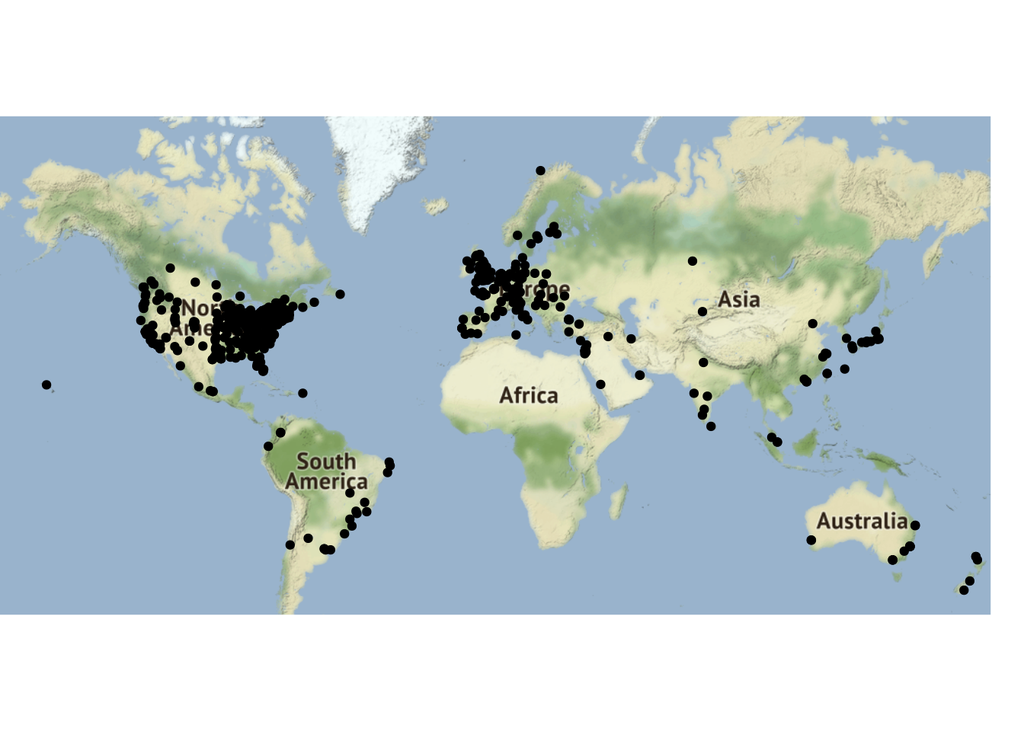

```r
ggmap::qmplot(lon, lat,
              data = inst_df,
              geom = "point")
```

## With AIs

```r
with_ais <- inst_df %>%
  dplyr::filter(., n_auth_invest > 0)
```

Most institutions have one Authorized Investigator.

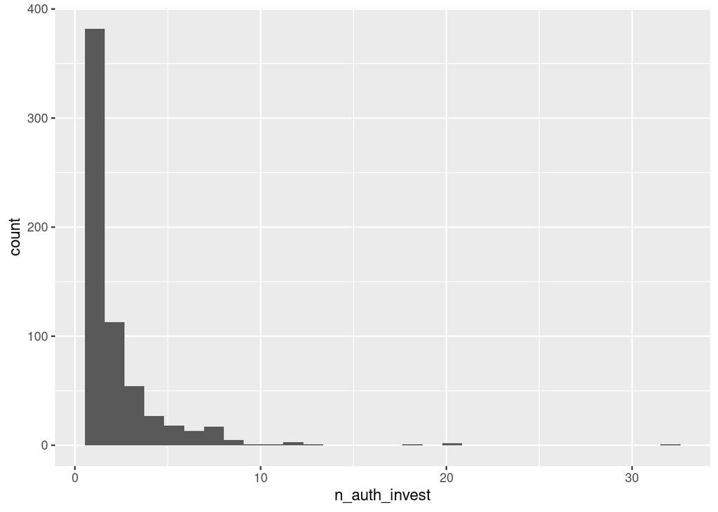

```r
ggplot(with_ais) +
  aes(n_auth_invest) +
  geom_histogram()
```

```r
gte5_ais <- with_ais %>%
  dplyr::filter(., n_auth_invest >= 5) %>%
  dplyr::mutate(., db_url = paste0("https://nyu.databrary.org/party/", inst_id))
```

```r
gte5_ais %>%
  dplyr::arrange(., desc(n_auth_invest)) %>%
  dplyr::select(., inst_id, inst_name, db_url, n_auth_invest) %>%
  kableExtra::kbl(.) %>%
  kableExtra::kable_styling()
```

| inst_id | inst_name | db_url | n_auth_invest |
| --- | --- | --- | --- |
| 8 | New York University (NYU) | https://nyu.databrary.org/party/8 | 32 |
| 12 | Pennsylvania State University, University Park | https://nyu.databrary.org/party/12 | 20 |
| 236 | University of Toronto | https://nyu.databrary.org/party/236 | 20 |
| 137 | University of Maryland, College Park | https://nyu.databrary.org/party/137 | 18 |
| 225 | University of Iowa | https://nyu.databrary.org/party/225 | 13 |
| 179 | Boston University | https://nyu.databrary.org/party/179 | 12 |
| 201 | Northwestern University | https://nyu.databrary.org/party/201 | 12 |
| 215 | University of British Columbia, Vancouver | https://nyu.databrary.org/party/215 | 12 |
| 43 | University of Wisconsin, Madison | https://nyu.databrary.org/party/43 | 11 |
| 44 | University of Michigan | https://nyu.databrary.org/party/44 | 10 |
| 54 | University of Virginia | https://nyu.databrary.org/party/54 | 9 |
| 171 | Stanford University | https://nyu.databrary.org/party/171 | 9 |
| 203 | Ohio State University | https://nyu.databrary.org/party/203 | 9 |
| 1505 | New York University, School of Medicine | https://nyu.databrary.org/party/1505 | 9 |
| 1817 | Leiden University | https://nyu.databrary.org/party/1817 | 9 |
| 57 | University of Texas at Austin | https://nyu.databrary.org/party/57 | 8 |
| 176 | Arizona State University | https://nyu.databrary.org/party/176 | 8 |
| 216 | University of California, Davis | https://nyu.databrary.org/party/216 | 8 |
| 217 | University of California, Los Angeles | https://nyu.databrary.org/party/217 | 8 |
| 931 | Radboud University | https://nyu.databrary.org/party/931 | 8 |
| 1068 | Purdue University | https://nyu.databrary.org/party/1068 | 8 |
| 2451 | University of Illinois at Urbana-Champaign | https://nyu.databrary.org/party/2451 | 8 |
| 51 | Rutgers University, Newark | https://nyu.databrary.org/party/51 | 7 |
| 55 | Indiana University | https://nyu.databrary.org/party/55 | 7 |
| 59 | University of Chicago | https://nyu.databrary.org/party/59 | 7 |
| 146 | Temple University | https://nyu.databrary.org/party/146 | 7 |
| 190 | Harvard University | https://nyu.databrary.org/party/190 | 7 |
| 199 | Northeastern University | https://nyu.databrary.org/party/199 | 7 |
| 220 | University of Connecticut | https://nyu.databrary.org/party/220 | 7 |
| 227 | University of Massachusetts, Amherst | https://nyu.databrary.org/party/227 | 7 |
| 1187 | University of North Carolina, Greensboro | https://nyu.databrary.org/party/1187 | 7 |
| 4305 | Nanyang Technological University | https://nyu.databrary.org/party/4305 | 7 |
| 119 | Vanderbilt University | https://nyu.databrary.org/party/119 | 6 |
| 134 | Yale University | https://nyu.databrary.org/party/134 | 6 |
| 142 | University of California, Riverside | https://nyu.databrary.org/party/142 | 6 |
| 166 | University of Oregon | https://nyu.databrary.org/party/166 | 6 |
| 186 | Emory University | https://nyu.databrary.org/party/186 | 6 |
| 391 | Michigan State University | https://nyu.databrary.org/party/391 | 6 |
| 1043 | Rochester Institute of Technology | https://nyu.databrary.org/party/1043 | 6 |
| 1055 | Oregon State University | https://nyu.databrary.org/party/1055 | 6 |
| 1364 | Princeton University | https://nyu.databrary.org/party/1364 | 6 |
| 1981 | Lancaster University | https://nyu.databrary.org/party/1981 | 6 |
| 2255 | University of Waterloo | https://nyu.databrary.org/party/2255 | 6 |
| 2376 | University of California, Irvine | https://nyu.databrary.org/party/2376 | 6 |
| 2452 | Cardiff University | https://nyu.databrary.org/party/2452 | 6 |
| 50 | Carnegie Mellon University (CMU) | https://nyu.databrary.org/party/50 | 5 |
| 52 | Rutgers University, New Brunswick | https://nyu.databrary.org/party/52 | 5 |
| 58 | McMaster University | https://nyu.databrary.org/party/58 | 5 |
| 112 | Brown University | https://nyu.databrary.org/party/112 | 5 |
| 113 | Tulane University | https://nyu.databrary.org/party/113 | 5 |
| 115 | Virginia Tech | https://nyu.databrary.org/party/115 | 5 |
| 157 | University of Pittsburgh | https://nyu.databrary.org/party/157 | 5 |
| 168 | University of Portsmouth | https://nyu.databrary.org/party/168 | 5 |
| 172 | College of Staten Island, CUNY | https://nyu.databrary.org/party/172 | 5 |
| 182 | Cornell University | https://nyu.databrary.org/party/182 | 5 |
| 193 | Johns Hopkins University | https://nyu.databrary.org/party/193 | 5 |
| 195 | Massachusetts Institute of Technology | https://nyu.databrary.org/party/195 | 5 |
| 213 | University of Arizona | https://nyu.databrary.org/party/213 | 5 |
| 228 | University of Minnesota | https://nyu.databrary.org/party/228 | 5 |
| 237 | University of Washington | https://nyu.databrary.org/party/237 | 5 |
| 281 | Utrecht University | https://nyu.databrary.org/party/281 | 5 |
| 977 | University of Pennsylvania | https://nyu.databrary.org/party/977 | 5 |
| 2282 | University of North Carolina, Chapel Hill | https://nyu.databrary.org/party/2282 | 5 |

## Without AIs

```r
no_ais <- inst_df %>%
  dplyr::filter(., n_auth_invest == 0) %>%
  dplyr::mutate(., db_url = paste0("https://nyu.databrary.org/party/", inst_id))
```

The following institutions do not have authorized investigators:

```r
no_ais %>%
  dplyr::select(., inst_id, inst_name, db_url, n_auth_invest, daa) %>%
  kableExtra::kbl(.) %>%
  kableExtra::kable_styling()
```

| inst_id | inst_name | db_url | n_auth_invest | daa |
| --- | --- | --- | --- | --- |
| 2 | Staff | https://nyu.databrary.org/party/2 | 0 | FALSE |
| 9 | National Science Foundation (NSF) | https://nyu.databrary.org/party/9 | 0 | FALSE |
| 10 | National Institutes of Health (NIH) | https://nyu.databrary.org/party/10 | 0 | FALSE |
| 15 | National Institute of Child Health and Human Development (NICHD) | https://nyu.databrary.org/party/15 | 0 | FALSE |
| 47 | Okinawa Institute of Science and Technology (OIST) | https://nyu.databrary.org/party/47 | 0 | FALSE |
| 122 | New York State Institute for Basic Research in Developmental Disabilities | https://nyu.databrary.org/party/122 | 0 | FALSE |
| 139 | University of Sheffield | https://nyu.databrary.org/party/139 | 0 | FALSE |
| 156 | University of Hartford | https://nyu.databrary.org/party/156 | 0 | FALSE |
| 169 | University of Redlands | https://nyu.databrary.org/party/169 | 0 | FALSE |
| 175 | Albert Einstein College of Medicine | https://nyu.databrary.org/party/175 | 0 | TRUE |
| 180 | Bucknell University | https://nyu.databrary.org/party/180 | 0 | FALSE |
| 183 | Dartmouth College | https://nyu.databrary.org/party/183 | 0 | FALSE |
| 204 | Ramapo College | https://nyu.databrary.org/party/204 | 0 | FALSE |
| 205 | University of Rennes 2 | https://nyu.databrary.org/party/205 | 0 | FALSE |
| 208 | Smith-Kettlewell Eye Research Institute | https://nyu.databrary.org/party/208 | 0 | FALSE |
| 209 | Southern Illinois University | https://nyu.databrary.org/party/209 | 0 | FALSE |
| 210 | St Francis Xavier University | https://nyu.databrary.org/party/210 | 0 | FALSE |
| 214 | University of Bristol | https://nyu.databrary.org/party/214 | 0 | FALSE |
| 219 | University of Cleveland | https://nyu.databrary.org/party/219 | 0 | FALSE |
| 223 | University of Illinois | https://nyu.databrary.org/party/223 | 0 | FALSE |
| 230 | University of Nebraska | https://nyu.databrary.org/party/230 | 0 | FALSE |
| 231 | University of North Carolina | https://nyu.databrary.org/party/231 | 0 | FALSE |
| 238 | University of Western Sydney | https://nyu.databrary.org/party/238 | 0 | FALSE |
| 243 | Université de Bretagne Sud | https://nyu.databrary.org/party/243 | 0 | FALSE |
| 295 | Liverpool University | https://nyu.databrary.org/party/295 | 0 | FALSE |
| 312 | National Institute on Deafness and Communication Disorders | https://nyu.databrary.org/party/312 | 0 | FALSE |
| 382 | New York State Psychiatric Institute | https://nyu.databrary.org/party/382 | 0 | FALSE |
| 1058 | South Carolina | https://nyu.databrary.org/party/1058 | 0 | FALSE |
| 1354 | Montana State University | https://nyu.databrary.org/party/1354 | 0 | TRUE |
| 1368 | Rhodes College | https://nyu.databrary.org/party/1368 | 0 | TRUE |
| 1427 | IRCCS Stella Maris Foundation | https://nyu.databrary.org/party/1427 | 0 | FALSE |
| 2402 | University of Wisconsin, Oshkosh | https://nyu.databrary.org/party/2402 | 0 | TRUE |
| 2555 | Massachusetts Institute of Technology | https://nyu.databrary.org/party/2555 | 0 | FALSE |
| 2873 | Carlos Albizu University, San Juan | https://nyu.databrary.org/party/2873 | 0 | TRUE |
| 5235 | College of Southern Nevada | https://nyu.databrary.org/party/5235 | 0 | TRUE |
| 5300 | MedStar Health Research Institute | https://nyu.databrary.org/party/5300 | 0 | TRUE |
| 5327 | Viterbo University | https://nyu.databrary.org/party/5327 | 0 | TRUE |
| 5417 | Muppets University | https://nyu.databrary.org/party/5417 | 0 | FALSE |
| 5458 | University of Missouri, Columbia | https://nyu.databrary.org/party/5458 | 0 | TRUE |
| 5562 | New University of Lisbon | https://nyu.databrary.org/party/5562 | 0 | TRUE |
| 5705 | Pennsylvania State University, Worthington-Scranton | https://nyu.databrary.org/party/5705 | 0 | TRUE |
| 6065 | University of Osnabrueck | https://nyu.databrary.org/party/6065 | 0 | FALSE |
| 8545 | Machado | https://nyu.databrary.org/party/8545 | 0 | FALSE |

Of these, the following appear to have an active authorization from Databrary, meaning an active Databrary Access Agreement (DAA):

```r
no_ais %>%
  dplyr::filter(., daa == TRUE) %>%
  dplyr::select(., inst_id, inst_name, db_url, n_auth_invest, daa) %>%
  kableExtra::kbl(.) %>%
  kableExtra::kable_styling()
```

| inst_id | inst_name | db_url | n_auth_invest | daa |
| --- | --- | --- | --- | --- |
| 175 | Albert Einstein College of Medicine | https://nyu.databrary.org/party/175 | 0 | TRUE |
| 1354 | Montana State University | https://nyu.databrary.org/party/1354 | 0 | TRUE |
| 1368 | Rhodes College | https://nyu.databrary.org/party/1368 | 0 | TRUE |
| 2402 | University of Wisconsin, Oshkosh | https://nyu.databrary.org/party/2402 | 0 | TRUE |
| 2873 | Carlos Albizu University, San Juan | https://nyu.databrary.org/party/2873 | 0 | TRUE |
| 5235 | College of Southern Nevada | https://nyu.databrary.org/party/5235 | 0 | TRUE |
| 5300 | MedStar Health Research Institute | https://nyu.databrary.org/party/5300 | 0 | TRUE |
| 5327 | Viterbo University | https://nyu.databrary.org/party/5327 | 0 | TRUE |
| 5458 | University of Missouri, Columbia | https://nyu.databrary.org/party/5458 | 0 | TRUE |
| 5562 | New University of Lisbon | https://nyu.databrary.org/party/5562 | 0 | TRUE |
| 5705 | Pennsylvania State University, Worthington-Scranton | https://nyu.databrary.org/party/5705 | 0 | TRUE |